# Analysis of First Pass Regressions Out

Henrik Singmann

17 October, 2017

```r
require(dplyr)
require(tidyr)
require(stringr)
require(ggplot2)
require(afex)
require(lattice) # for qqmath
require(gridExtra)
theme_set(theme_light())
require(optimx)
require(DHARMa) # for residual analysis
#require(binom)
require(effects)
```

# Introduction

The goal of the following analysis was to see whether the explanatory goodness of fit would affect the DVs. For detailed analysis of the IVs see other file.

```r
data_in <- read.csv("RO_plus_ratings.csv")
data_in$P.s <- factor(data_in$P.s)
data_in$Item <- factor(data_in$Item)
```

# First pass Regression Outs

## Data Preparation

```r
drp_r <- droplevels(data_in[data_in$Item != "9" ,])
nas <- is.na(drp_r$spillover) | is.na(drp_r$Consequent)
drp_r <- droplevels(drp_r[!nas,])
```

For the analysis we remove 0 trials with missing data in either spillover or Consequent. Then we z-transform the continuous `Accepts` variable.

```r
drp_r <- drp_r %>%
  mutate(
    acc_z = (Accepts - mean(Accepts))/sd(Accepts))
    #conf_z = (Confident- mean(Confident))/sd(Confident))
```

# Consequent

Note that the maximal model for models including `Fit` have random slopes for `Fit` for both random effects grouping factors (i.e., participant `P.s` and `Item`). For models including the continuous fit measure `Accepts` we have by-participant random slopes for `Accepts`, but by-item random slopes for `Fit` (as `Accepts` has only two different values for each `Item`, using the binary `Fit` variable seems more reasonable.)

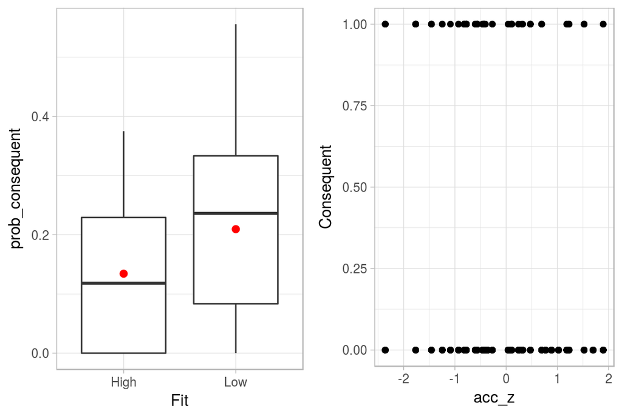

```r
agg <- drp_r %>%
  group_by(P.s, Fit) %>%
  summarise(prob_consequent = mean(Consequent),
            prob_spillover = mean(spillover),
            consequent = sum(Consequent),
            spillover = sum(spillover),
            n = n()) %>%
  ungroup

p_obs_acc <- ggplot(data = drp_r, aes(x = acc_z, y = Consequent)) +
  geom_point()

p_obs_fit <- ggplot(agg, aes(x = Fit, y = prob_consequent)) +
  geom_boxplot() +
   stat_summary(fun.y = "mean", colour = "red", size = 2, geom = "point")
grid.arrange(p_obs_fit, p_obs_acc, ncol = 2)
```

## With Fit

```r
m_con_f_1 <- mixed(Consequent ~ Fit + (Fit|P.s) + (Fit| Item), drp_r, family = binomial, method = "LRT", progress = FALSE)
```

```
## Contrasts set to contr.sum for the following variables: Fit, P.s, Item
```

```r
summary(m_con_f_1)
```

```
## Generalized linear mixed model fit by maximum likelihood (Laplace
##   Approximation) [glmerMod]
##  Family: binomial  ( logit )
## Formula: Consequent ~ Fit + (Fit | P.s) + (Fit | Item)
##    Data: drp_r
##
##      AIC      BIC   logLik deviance df.resid
##    375.5    407.6   -179.8    359.5      400
##
## Scaled residuals:
##     Min      1Q  Median      3Q     Max
## -0.9118 -0.4518 -0.3606 -0.2590  3.3755
##
## Random effects:
##  Groups Name        Variance Std.Dev. Corr
##  P.s    (Intercept) 0.27726  0.5266
##         Fit1        0.02595  0.1611   -1.00
##  Item   (Intercept) 0.48340  0.6953
##         Fit1        0.03395  0.1843   -1.00
## Number of obs: 408, groups:  P.s, 24; Item, 17
##
## Fixed effects:
##             Estimate Std. Error z value Pr(>|z|)
## (Intercept)  -1.8276     0.2625  -6.962 3.34e-12 ***
## Fit1         -0.1875     0.1766  -1.062    0.288
## ---
## Signif. codes:  0 '***' 0.001 '**' 0.01 '*' 0.05 '.' 0.1 ' ' 1
##
## Correlation of Fixed Effects:
##      (Intr)
## Fit1 -0.231
```

The correlations between the random effects parameters are at the boundary of the parameter space, consequently we remove those.

```r
m_con_f_2 <- mixed(Consequent ~ Fit + (Fit||P.s) + (Fit|| Item), drp_r, family = binomial, method = "LRT", progress = FALSE, expand_re = TRUE)
```

```
## Contrasts set to contr.sum for the following variables: Fit, P.s, Item
```

```r
summary(m_con_f_2)
```

```
## Generalized linear mixed model fit by maximum likelihood (Laplace
##   Approximation) [glmerMod]
##  Family: binomial  ( logit )
## Formula: Consequent ~ Fit + (1 + re1.Fit1 || P.s) + (1 + re2.Fit1 || Item)
##    Data: drp_r
##
##      AIC      BIC   logLik deviance df.resid
##    372.7    396.7   -180.3    360.7      402
##
## Scaled residuals:
##     Min      1Q  Median      3Q     Max
## -0.8320 -0.4650 -0.3634 -0.2489  3.5464
##
## Random effects:
##  Groups Name        Variance  Std.Dev.
##  P.s    (Intercept) 2.738e-01 0.523226
##  P.s.1  re1.Fit1    7.046e-06 0.002654
##  Item   (Intercept) 5.112e-01 0.714960
##  Item.1 re2.Fit1    1.681e-02 0.129653
## Number of obs: 408, groups:  P.s, 24; Item, 17
##
## Fixed effects:
##              Estimate Std. Error z value Pr(>|z|)
## (Intercept) -1.844720   0.001649 -1118.8   <2e-16 ***
## Fit1        -0.305268   0.001649  -185.1   <2e-16 ***
## ---
## Signif. codes:  0 '***' 0.001 '**' 0.01 '*' 0.05 '.' 0.1 ' ' 1
##
## Correlation of Fixed Effects:
##      (Intr)
## Fit1 0.001
## convergence code: 0
## Model failed to converge with max|grad| = 0.0428388 (tol = 0.001, component 1)
```

Now the by-participant random slope for `Fit` is very small, so we consequently refit the model without that parameter, we also try all available optimizer to see if this helps.

```r
m_con_f_3 <- mixed(Consequent ~ Fit + (1|P.s) + (Fit|| Item), drp_r, family = binomial, method = "LRT", progress = FALSE, expand_re = TRUE, all_fit = TRUE)
```

```
## Contrasts set to contr.sum for the following variables: Fit, P.s, Item
```

```r
summary(m_con_f_3)
```

```
## Generalized linear mixed model fit by maximum likelihood (Laplace
##   Approximation) [glmerMod]
##  Family: binomial  ( logit )
## Formula: Consequent ~ Fit + (1 | P.s) + (1 + re2.Fit1 || Item)
##    Data: drp_r
##
##      AIC      BIC   logLik deviance df.resid
##    370.7    390.7   -180.3    360.7      403
##
## Scaled residuals:
##     Min      1Q  Median      3Q     Max
## -0.8315 -0.4656 -0.3637 -0.2486  3.5538
##
## Random effects:
##  Groups Name        Variance Std.Dev.
##  P.s    (Intercept) 0.27385  0.5233
##  Item   (Intercept) 0.51233  0.7158
##  Item.1 re2.Fit1    0.01549  0.1244
## Number of obs: 408, groups:  P.s, 24; Item, 17
##
## Fixed effects:
##              Estimate Std. Error z value Pr(>|z|)
## (Intercept) -1.845660   0.001651 -1117.9   <2e-16 ***
## Fit1        -0.305718   0.001651  -185.2   <2e-16 ***
## ---
## Signif. codes:  0 '***' 0.001 '**' 0.01 '*' 0.05 '.' 0.1 ' ' 1
##
## Correlation of Fixed Effects:
##      (Intr)
## Fit1 0.001
## convergence code: 0
## Model failed to converge with max|grad| = 0.0427983 (tol = 0.001, component 1)
```

Overall, the final model seems to provide the best account (i.e., is the optimal model).

```r
anova(m_con_f_1, m_con_f_2, m_con_f_3)
```

```
## Data: drp_r
## Models:
## m_con_f_3: Consequent ~ Fit + (1 | P.s) + (1 + re2.Fit1 || Item)
## m_con_f_2: Consequent ~ Fit + (1 + re1.Fit1 || P.s) + (1 + re2.Fit1 || Item)
## m_con_f_1: Consequent ~ Fit + (Fit | P.s) + (Fit | Item)
##           Df    AIC    BIC  logLik deviance  Chisq Chi Df Pr(>Chisq)
## m_con_f_3  5 370.67 390.73 -180.34   360.67
## m_con_f_2  6 372.67 396.74 -180.34   360.67 0.0000      1      1.000
## m_con_f_1  8 375.52 407.61 -179.76   359.52 1.1489      2      0.563
```

Is there are large difference between the different optimizers? No, all optimizers fit the models basically identically.

```r
attr(m_con_f_3, "all_fit_logLik")
```

```
##                               full_model       Fit
## default                        -180.3363 -182.2747
## bobyqa.                        -180.3379 -182.2782
## Nelder_Mead.                   -180.3363 -182.2747
## optimx.nlminb                  -180.3379 -182.2747
## optimx.L-BFGS-B                -180.3383 -182.2782
## nloptwrap.NLOPT_LN_NELDERMEAD  -180.3394 -182.2749
## nloptwrap.NLOPT_LN_BOBYQA      -180.3394 -182.2749
## nmkbw.                         -180.3363 -182.2748
```

We also perform some graphical model fit tests (using `DHARMa`, see: https://cran.r-project.org/web/packages/DHARMa/vignettes/DHARMa.html) which suggest the model is without large problems (i.e., for the QQ-plot the residuals are on the main diagonal and for the residuals versus predicted the red lines are straight and at .25, .5 and .75).

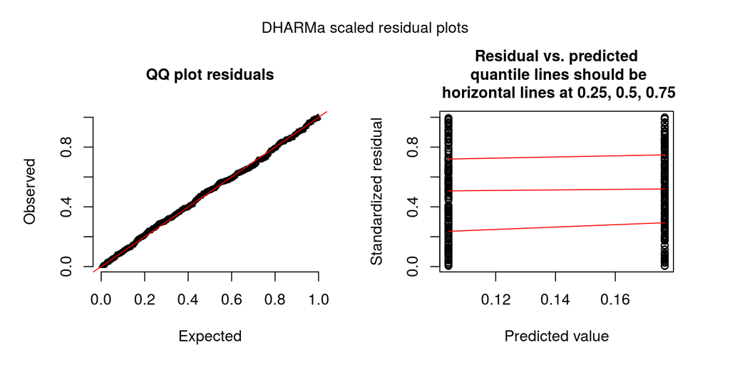

```r
sim_m_con_f_3 <- simulateResiduals(fittedModel = m_con_f_3$full_model, n = 250)
plotSimulatedResiduals(sim_m_con_f_3)
```

Interestingly, only for the optimal model but not for the maximal model is the effetc of Fit significant.

```r
nice(m_con_f_1)
```

```
## Mixed Model Anova Table (Type 3 tests, LRT-method)
##
## Model: Consequent ~ Fit + (Fit | P.s) + (Fit | Item)
## Data: drp_r
## Df full model: 8
##   Effect df Chisq p.value
## 1    Fit  1  0.88     .35
## ---
## Signif. codes:  0 '***' 0.001 '**' 0.01 '*' 0.05 '+' 0.1 ' ' 1
```

```r
nice(m_con_f_3)
```

```
## Mixed Model Anova Table (Type 3 tests, LRT-method)
##
## Model: Consequent ~ Fit + (1 | P.s) + (Fit || Item)
## Data: drp_r
## Df full model: 5
##   Effect df  Chisq p.value
## 1    Fit  1 3.88 *     .05
## ---
## Signif. codes:  0 '***' 0.001 '**' 0.01 '*' 0.05 '+' 0.1 ' ' 1
```

```r
m_con_a_1 <- mixed(Consequent ~ acc_z + (acc_z|P.s) + (Fit| Item), drp_r, family = binomial, method = "LRT", progress = FALSE)
```

```
## Contrasts set to contr.sum for the following variables: P.s, Fit, Item
```

```r
summary(m_con_a_1)
```

```
## Generalized linear mixed model fit by maximum likelihood (Laplace
##   Approximation) [glmerMod]
##  Family: binomial  ( logit )
## Formula: Consequent ~ acc_z + (acc_z | P.s) + (Fit | Item)
##    Data: drp_r
##
##      AIC      BIC   logLik deviance df.resid
##    372.0    404.1   -178.0    356.0      400
##
## Scaled residuals:
##     Min      1Q  Median      3Q     Max
## -1.1334 -0.4400 -0.3546 -0.2716  3.5298
##
## Random effects:
##  Groups Name        Variance Std.Dev. Corr
##  P.s    (Intercept) 0.26566  0.5154
##         acc_z       0.06198  0.2490   -1.00
##  Item   (Intercept) 0.29283  0.5411
##         Fit1        0.01768  0.1330   -0.50
## Number of obs: 408, groups:  P.s, 24; Item, 17
##
## Fixed effects:
##             Estimate Std. Error z value Pr(>|z|)
## (Intercept)  -1.8100     0.2406  -7.522 5.41e-14 ***
## acc_z        -0.3305     0.2323  -1.423    0.155
## ---
## Signif. codes:  0 '***' 0.001 '**' 0.01 '*' 0.05 '.' 0.1 ' ' 1
##
## Correlation of Fixed Effects:
##       (Intr)
## acc_z -0.029
```

We see a suspcisouly high correlations between the by-participant random effect parameters, consequently we remove it.

```r
m_con_a_2 <- mixed(Consequent ~ acc_z + (acc_z||P.s) + (Fit|Item), drp_r, family = binomial, method = "LRT", progress = FALSE, expand_re = TRUE, all_fit = TRUE)
```

```
## Contrasts set to contr.sum for the following variables: P.s, Fit, Item
```

```r
summary(m_con_a_2)
```

```
## Generalized linear mixed model fit by maximum likelihood (Laplace
##   Approximation) [glmerMod]
##  Family: binomial  ( logit )
## Formula: Consequent ~ acc_z + (1 + re1.acc_z || P.s) + (1 + re2.Fit1 |
##     Item)
##    Data: drp_r
## Control: ctrl
##
##      AIC      BIC   logLik deviance df.resid
##    371.3    399.4   -178.7    357.3      401
##
## Scaled residuals:
##     Min      1Q  Median      3Q     Max
## -0.9442 -0.4616 -0.3635 -0.2611  3.8246
##
## Random effects:
##  Groups Name        Variance  Std.Dev. Corr
##  P.s    (Intercept) 0.2741995 0.52364
##  P.s.1  re1.acc_z   0.0002019 0.01421
##  Item   (Intercept) 0.2528077 0.50280
##         re2.Fit1    0.0340696 0.18458  -0.06
## Number of obs: 408, groups:  P.s, 24; Item, 17
##
## Fixed effects:
##             Estimate Std. Error z value Pr(>|z|)
## (Intercept)  -1.8159     0.2457  -7.390 1.46e-13 ***
## acc_z        -0.4395     0.2063  -2.131   0.0331 *
## ---
## Signif. codes:  0 '***' 0.001 '**' 0.01 '*' 0.05 '.' 0.1 ' ' 1
##
## Correlation of Fixed Effects:
##       (Intr)
## acc_z 0.175
```

Given the small estimate of the by-participant random slope we remove it.

```r
m_con_a_3 <- mixed(Consequent ~ acc_z + (1|P.s) + (Fit|Item), drp_r, family = binomial, method = "LRT", progress = FALSE, expand_re = FALSE, all_fit = TRUE)
```

```
## Contrasts set to contr.sum for the following variables: P.s, Fit, Item
```

```r
summary(m_con_a_3)
```

```
## Generalized linear mixed model fit by maximum likelihood (Laplace
##   Approximation) [glmerMod]
##  Family: binomial  ( logit )
## Formula: Consequent ~ acc_z + (1 | P.s) + (Fit | Item)
##    Data: drp_r
## Control: ctrl
##
##      AIC      BIC   logLik deviance df.resid
##    369.3    393.4   -178.7    357.3      402
##
## Scaled residuals:
##     Min      1Q  Median      3Q     Max
## -0.9442 -0.4616 -0.3636 -0.2610  3.8258
##
## Random effects:
##  Groups Name        Variance Std.Dev. Corr
##  P.s    (Intercept) 0.27424  0.5237
##  Item   (Intercept) 0.25281  0.5028
##         Fit1        0.03405  0.1845   -0.06
## Number of obs: 408, groups:  P.s, 24; Item, 17
##
## Fixed effects:
##             Estimate Std. Error z value Pr(>|z|)
## (Intercept)  -1.8158     0.2437  -7.452 9.18e-14 ***
## acc_z        -0.4395     0.2062  -2.131   0.0331 *
## ---
## Signif. codes:  0 '***' 0.001 '**' 0.01 '*' 0.05 '.' 0.1 ' ' 1
##
## Correlation of Fixed Effects:
##       (Intr)
## acc_z 0.175
```

```r
anova(m_con_a_1, m_con_a_2, m_con_a_3)
```

```
## Data: drp_r
## Models:
## m_con_a_3: Consequent ~ acc_z + (1 | P.s) + (Fit | Item)
## m_con_a_2: Consequent ~ acc_z + (1 + re1.acc_z || P.s) + (1 + re2.Fit1 |
## m_con_a_2:     Item)
## m_con_a_1: Consequent ~ acc_z + (acc_z | P.s) + (Fit | Item)
##           Df    AIC    BIC  logLik deviance  Chisq Chi Df Pr(>Chisq)
## m_con_a_3  6 369.32 393.39 -178.66   357.32
## m_con_a_2  7 371.32 399.40 -178.66   357.32 0.0000      1     0.9988
## m_con_a_1  8 372.04 404.13 -178.02   356.04 1.2779      1     0.2583
```

Again, the reduced model seems to be the optimal model. Consequently we also inspect the residuals of this model. Overall this also looks very reasonable.

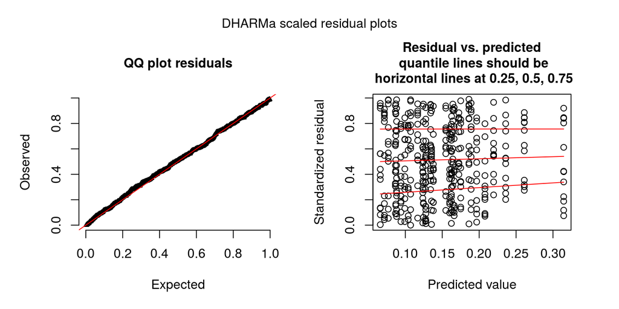

```r
sim_m_con_a_3 <- simulateResiduals(fittedModel = m_con_a_3$full_model, n = 500)
plotSimulatedResiduals(sim_m_con_a_3)
```

For the optimal model we find a significant effect of `Accepts` (z-transformed to `acc_z`).

```r
nice(m_con_a_1)
```

```
## Mixed Model Anova Table (Type 3 tests, LRT-method)
##
## Model: Consequent ~ acc_z + (acc_z | P.s) + (Fit | Item)
## Data: drp_r
## Df full model: 8
##   Effect df Chisq p.value
## 1  acc_z  1  2.14     .14
## ---
## Signif. codes:  0 '***' 0.001 '**' 0.01 '*' 0.05 '+' 0.1 ' ' 1
```

```r
nice(m_con_a_3)
```

```
## Mixed Model Anova Table (Type 3 tests, LRT-method)
##
## Model: Consequent ~ acc_z + (1 | P.s) + (Fit | Item)
## Data: drp_r
## Df full model: 6
##   Effect df  Chisq p.value
## 1  acc_z  1 4.70 *     .03
## ---
## Signif. codes:  0 '***' 0.001 '**' 0.01 '*' 0.05 '+' 0.1 ' ' 1
```

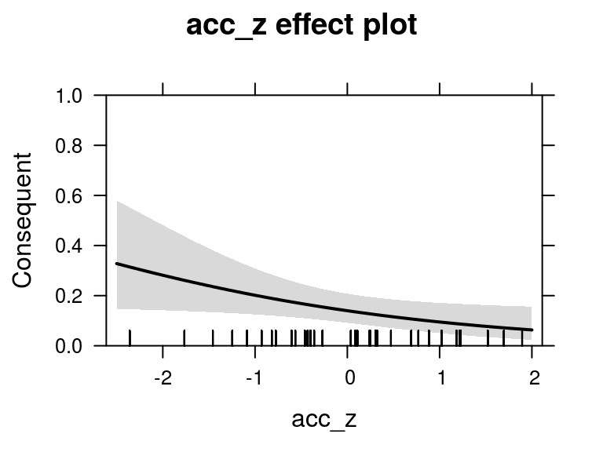

```r
plot(Effect("acc_z", m_con_a_3$full_model,
            xlevels = list(acc_z = seq(-2.5, 2, by = 0.25))),
     ylim = c(0,1), type = "response")
```

# Spillover

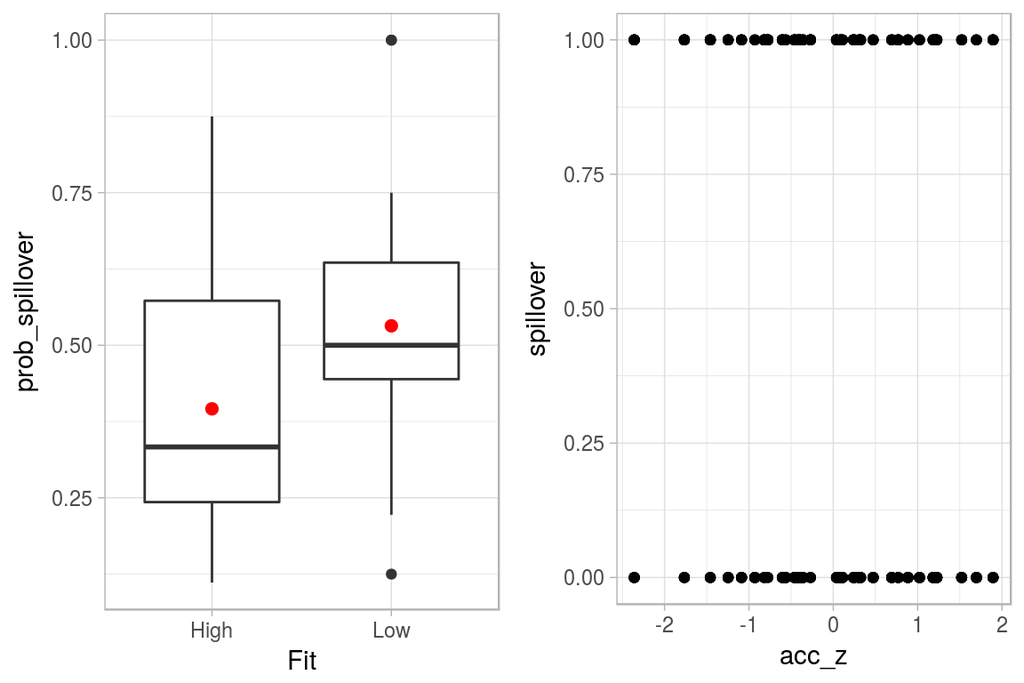

```r
p_obs_acc <- ggplot(data = drp_r, aes(x = acc_z, y = spillover)) +
  geom_point()

p_obs_fit <- ggplot(agg, aes(x = Fit, y = prob_spillover)) +
  geom_boxplot() +
   stat_summary(fun.y = "mean", colour = "red", size = 2, geom = "point")
grid.arrange(p_obs_fit, p_obs_acc, ncol = 2)
```

## With Fit

```r
m_spill_f_1 <- mixed(spillover ~ Fit + (Fit|P.s) + (Fit| Item), drp_r, family = binomial, method = "LRT", progress = FALSE)
```

```
## Contrasts set to contr.sum for the following variables: Fit, P.s, Item
```

```r
summary(m_spill_f_1)
```

```
## Generalized linear mixed model fit by maximum likelihood (Laplace
##   Approximation) [glmerMod]
##  Family: binomial  ( logit )
## Formula: spillover ~ Fit + (Fit | P.s) + (Fit | Item)
##    Data: drp_r
##
##      AIC      BIC   logLik deviance df.resid
##    557.2    589.3   -270.6    541.2      400
##
## Scaled residuals:
##     Min      1Q  Median      3Q     Max
## -1.5340 -0.8306 -0.5507  0.9246  2.0041
##
## Random effects:
##  Groups Name        Variance Std.Dev. Corr
##  P.s    (Intercept) 0.425698 0.65246
##         Fit1        0.004814 0.06938  1.00
##  Item   (Intercept) 0.047930 0.21893
##         Fit1        0.015268 0.12357  -1.00
## Number of obs: 408, groups:  P.s, 24; Item, 17
##
## Fixed effects:
##             Estimate Std. Error z value Pr(>|z|)
## (Intercept)  -0.1658     0.1787  -0.928  0.35340
## Fit1         -0.3037     0.1115  -2.723  0.00646 **
## ---
## Signif. codes:  0 '***' 0.001 '**' 0.01 '*' 0.05 '.' 0.1 ' ' 1
##
## Correlation of Fixed Effects:
##      (Intr)
## Fit1 0.035
```

Due to the large correlation between the by-participants and by-item random-effects parameters we refit the model without the correlations.

```r
m_spill_f_2 <- mixed(spillover ~ Fit + (Fit||P.s) + (Fit|| Item), drp_r, family = binomial, method = "LRT", progress = FALSE, expand_re = TRUE)
```

```
## Contrasts set to contr.sum for the following variables: Fit, P.s, Item
```

```r
summary(m_spill_f_2)
```

```
## Generalized linear mixed model fit by maximum likelihood (Laplace
##   Approximation) [glmerMod]
##  Family: binomial  ( logit )
## Formula: spillover ~ Fit + (1 + re1.Fit1 || P.s) + (1 + re2.Fit1 || Item)
##    Data: drp_r
##
##      AIC      BIC   logLik deviance df.resid
##    554.2    578.3   -271.1    542.2      402
##
## Scaled residuals:
##     Min      1Q  Median      3Q     Max
## -1.5001 -0.8378 -0.5687  0.9760  1.9019
##
## Random effects:
##  Groups Name        Variance Std.Dev.
##  P.s    (Intercept) 0.41982  0.6479
##  P.s.1  re1.Fit1    0.00000  0.0000
##  Item   (Intercept) 0.02023  0.1422
##  Item.1 re2.Fit1    0.00000  0.0000
## Number of obs: 408, groups:  P.s, 24; Item, 17
##
## Fixed effects:
##             Estimate Std. Error z value Pr(>|z|)
## (Intercept)  -0.1611     0.1725  -0.934  0.35041
## Fit1         -0.3006     0.1059  -2.838  0.00454 **
## ---
## Signif. codes:  0 '***' 0.001 '**' 0.01 '*' 0.05 '.' 0.1 ' ' 1
##
## Correlation of Fixed Effects:
##      (Intr)
## Fit1 0.014
```

Now both random slopes are estimated to be zero, we consequently refit the model without those parameters.

```r
m_spill_f_3 <- mixed(spillover ~ Fit + (1|P.s) + (1| Item), drp_r, family = binomial, method = "LRT", progress = FALSE)
```

```
## Contrasts set to contr.sum for the following variables: Fit, P.s, Item
```

```r
summary(m_spill_f_3)
```

```
## Generalized linear mixed model fit by maximum likelihood (Laplace
##   Approximation) [glmerMod]
##  Family: binomial  ( logit )
## Formula: spillover ~ Fit + (1 | P.s) + (1 | Item)
##    Data: drp_r
##
##      AIC      BIC   logLik deviance df.resid
##    550.2    566.3   -271.1    542.2      404
##
## Scaled residuals:
##     Min      1Q  Median      3Q     Max
## -1.5001 -0.8378 -0.5687  0.9760  1.9019
##
## Random effects:
##  Groups Name        Variance Std.Dev.
##  P.s    (Intercept) 0.41981  0.6479
##  Item   (Intercept) 0.02023  0.1422
## Number of obs: 408, groups:  P.s, 24; Item, 17
##
## Fixed effects:
##             Estimate Std. Error z value Pr(>|z|)
## (Intercept)  -0.1611     0.1725  -0.934  0.35043
## Fit1         -0.3006     0.1059  -2.838  0.00454 **
## ---
## Signif. codes:  0 '***' 0.001 '**' 0.01 '*' 0.05 '.' 0.1 ' ' 1
##
## Correlation of Fixed Effects:
##      (Intr)
## Fit1 0.014
```

This model seems reasonable and only provides a minimally worse account than the first model.

```r
anova(m_spill_f_1, m_spill_f_3)
```

```
## Data: drp_r
## Models:
## m_spill_f_3: spillover ~ Fit + (1 | P.s) + (1 | Item)
## m_spill_f_1: spillover ~ Fit + (Fit | P.s) + (Fit | Item)
##             Df    AIC    BIC  logLik deviance  Chisq Chi Df Pr(>Chisq)
## m_spill_f_3  4 550.21 566.26 -271.11   542.21
## m_spill_f_1  8 557.23 589.32 -270.62   541.23 0.9785      4      0.913
```

The diagnistic plots look again regularly.

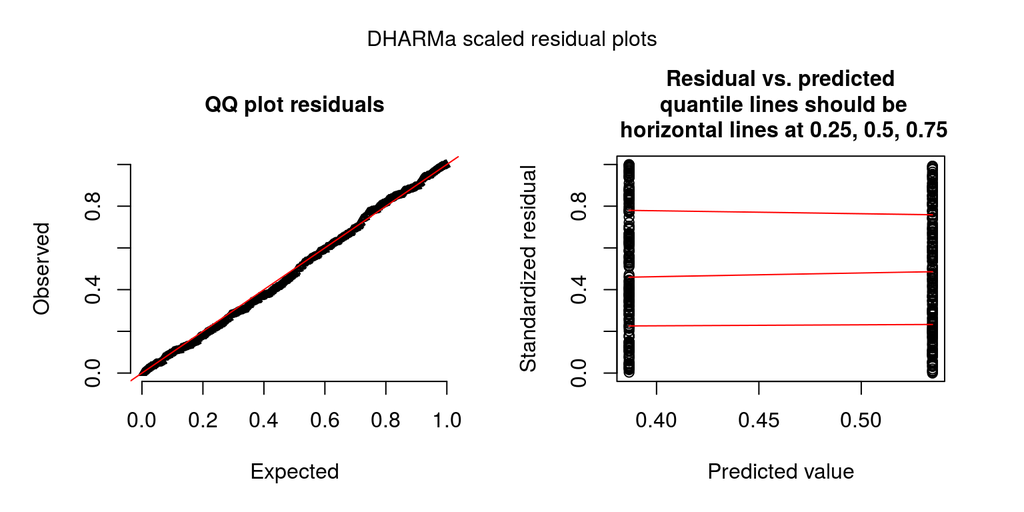

```r
sim_m_spill_f_3 <- simulateResiduals(fittedModel = m_spill_f_3$full_model, n = 500)
plotSimulatedResiduals(sim_m_spill_f_3)
```

The effect of Fit is significant for all models.

```r
nice(m_spill_f_1)
```

```
## Mixed Model Anova Table (Type 3 tests, LRT-method)
##
## Model: spillover ~ Fit + (Fit | P.s) + (Fit | Item)
## Data: drp_r
## Df full model: 8
##   Effect df   Chisq p.value
## 1    Fit  1 6.90 **    .009
## ---
## Signif. codes:  0 '***' 0.001 '**' 0.01 '*' 0.05 '+' 0.1 ' ' 1
```

```r
nice(m_spill_f_3)
```

```
## Mixed Model Anova Table (Type 3 tests, LRT-method)
##
## Model: spillover ~ Fit + (1 | P.s) + (1 | Item)
## Data: drp_r
## Df full model: 4
##   Effect df   Chisq p.value
## 1    Fit  1 8.18 **    .004
## ---
## Signif. codes:  0 '***' 0.001 '**' 0.01 '*' 0.05 '+' 0.1 ' ' 1
```

```r
m_spill_a_1 <- mixed(spillover ~ acc_z + (acc_z|P.s) + (Fit| Item), drp_r, family = binomial, method = "LRT", progress = FALSE)
```

```
## Contrasts set to contr.sum for the following variables: P.s, Fit, Item
```

```r
summary(m_spill_a_1)
```

```
## Generalized linear mixed model fit by maximum likelihood (Laplace
##   Approximation) [glmerMod]
##  Family: binomial  ( logit )
## Formula: spillover ~ acc_z + (acc_z | P.s) + (Fit | Item)
##    Data: drp_r
##
##      AIC      BIC   logLik deviance df.resid
##    556.3    588.4   -270.2    540.3      400
##
## Scaled residuals:
##     Min      1Q  Median      3Q     Max
## -1.7103 -0.8108 -0.5361  0.8784  2.0384
##
## Random effects:
##  Groups Name        Variance Std.Dev. Corr
##  P.s    (Intercept) 0.438777 0.66240
##         acc_z       0.111851 0.33444  0.65
##  Item   (Intercept) 0.058637 0.24215
##         Fit1        0.006951 0.08337  -1.00
## Number of obs: 408, groups:  P.s, 24; Item, 17
##
## Fixed effects:
##             Estimate Std. Error z value Pr(>|z|)
## (Intercept)  -0.1854     0.1832  -1.012   0.3115
## acc_z        -0.2949     0.1397  -2.111   0.0348 *
## ---
## Signif. codes:  0 '***' 0.001 '**' 0.01 '*' 0.05 '.' 0.1 ' ' 1
##
## Correlation of Fixed Effects:
##       (Intr)
## acc_z 0.221
```

We observe large correlations between the by-item random-effects parameters and we refit the model without the correlation.

```r
m_spill_a_2 <- mixed(spillover ~ acc_z + (acc_z|P.s) + (Fit|| Item), drp_r, family = binomial, method = "LRT", progress = FALSE, expand_re = TRUE)
```

```
## Contrasts set to contr.sum for the following variables: P.s, Fit, Item
```

```r
summary(m_spill_a_2)
```

```
## Generalized linear mixed model fit by maximum likelihood (Laplace
##   Approximation) [glmerMod]
##  Family: binomial  ( logit )
## Formula: spillover ~ acc_z + (1 + re1.acc_z | P.s) + (1 + re2.Fit1 ||
##     Item)
##    Data: drp_r
##
##      AIC      BIC   logLik deviance df.resid
##    554.7    582.7   -270.3    540.7      401
##
## Scaled residuals:
##     Min      1Q  Median      3Q     Max
## -1.7513 -0.8280 -0.5315  0.8754  1.9998
##
## Random effects:
##  Groups Name        Variance Std.Dev. Corr
##  P.s    (Intercept) 0.43878  0.6624
##         re1.acc_z   0.11290  0.3360   0.66
##  Item   (Intercept) 0.05178  0.2275
##  Item.1 re2.Fit1    0.00000  0.0000
## Number of obs: 408, groups:  P.s, 24; Item, 17
##
## Fixed effects:
##             Estimate Std. Error z value Pr(>|z|)
## (Intercept)  -0.1756     0.1811  -0.970   0.3323
## acc_z        -0.3038     0.1380  -2.202   0.0277 *
## ---
## Signif. codes:  0 '***' 0.001 '**' 0.01 '*' 0.05 '.' 0.1 ' ' 1
##
## Correlation of Fixed Effects:
##       (Intr)
## acc_z 0.281
```

As one random slopes is estimated to be zero, we consequently refit the model without this parameter.

```r
m_spill_a_3 <- mixed(spillover ~ acc_z + (acc_z|P.s) + (1| Item), drp_r, family = binomial, method = "LRT", progress = FALSE, expand_re = TRUE)
```

```
## Contrasts set to contr.sum for the following variables: P.s, Item
```

```r
summary(m_spill_a_3)
```

```
## Generalized linear mixed model fit by maximum likelihood (Laplace
##   Approximation) [glmerMod]
##  Family: binomial  ( logit )
## Formula: spillover ~ acc_z + (1 + re1.acc_z | P.s) + (1 | Item)
##    Data: drp_r
##
##      AIC      BIC   logLik deviance df.resid
##    552.7    576.7   -270.3    540.7      402
##
## Scaled residuals:
##     Min      1Q  Median      3Q     Max
## -1.7512 -0.8280 -0.5315  0.8754  1.9998
##
## Random effects:
##  Groups Name        Variance Std.Dev. Corr
##  P.s    (Intercept) 0.43876  0.6624
##         re1.acc_z   0.11289  0.3360   0.66
##  Item   (Intercept) 0.05177  0.2275
## Number of obs: 408, groups:  P.s, 24; Item, 17
##
## Fixed effects:
##             Estimate Std. Error z value Pr(>|z|)
## (Intercept)  -0.1756     0.1811  -0.970   0.3323
## acc_z        -0.3038     0.1380  -2.202   0.0277 *
## ---
## Signif. codes:  0 '***' 0.001 '**' 0.01 '*' 0.05 '.' 0.1 ' ' 1
##
## Correlation of Fixed Effects:
##       (Intr)
## acc_z 0.281
```

This model seems reasonable and only provides a minimally worse account than the first model.

```r
anova(m_spill_a_1, m_spill_a_3)
```

```
## Data: drp_r
## Models:
## m_spill_a_3: spillover ~ acc_z + (1 + re1.acc_z | P.s) + (1 | Item)
## m_spill_a_1: spillover ~ acc_z + (acc_z | P.s) + (Fit | Item)
##             Df    AIC    BIC  logLik deviance  Chisq Chi Df Pr(>Chisq)
## m_spill_a_3  6 552.65 576.72 -270.33   540.65
## m_spill_a_1  8 556.34 588.43 -270.17   540.34 0.3157      2      0.854
```

No issue with the diagnostic plots.

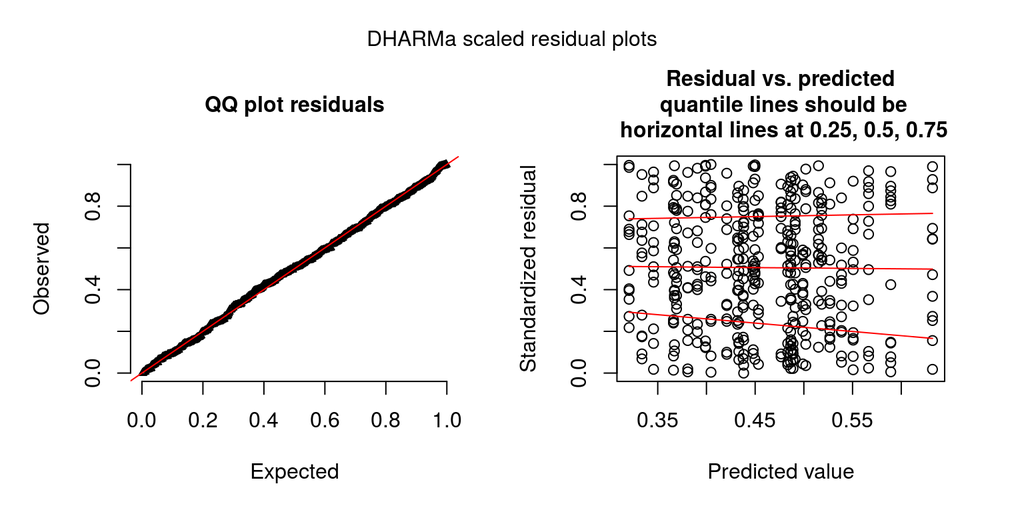

```r
sim_m_spill_a_3 <- simulateResiduals(fittedModel = m_spill_a_3$full_model, n = 500)
plotSimulatedResiduals(sim_m_spill_a_3)
```

The effect of `acc_z` is significant in both models.

```r
nice(m_spill_a_1)
```

```
## Mixed Model Anova Table (Type 3 tests, LRT-method)
##
## Model: spillover ~ acc_z + (acc_z | P.s) + (Fit | Item)
## Data: drp_r
## Df full model: 8
##   Effect df  Chisq p.value
## 1  acc_z  1 4.20 *     .04
## ---
## Signif. codes:  0 '***' 0.001 '**' 0.01 '*' 0.05 '+' 0.1 ' ' 1
```

```r
nice(m_spill_a_3)
```

```
## Mixed Model Anova Table (Type 3 tests, LRT-method)
##
## Model: spillover ~ acc_z + (acc_z | P.s) + (1 | Item)
## Data: drp_r
## Df full model: 6
##   Effect df  Chisq p.value
## 1  acc_z  1 4.76 *     .03
## ---
## Signif. codes:  0 '***' 0.001 '**' 0.01 '*' 0.05 '+' 0.1 ' ' 1
```